# 1. Linear algebra

## Creating numpy (or scipy) multi-dimensional arrays

Matrices are created in python using numpy (or scipy) arrays

```python
M = np.array([[1., 2],[0, -1]]) # creates a 2x2 matrix
M
```

```
array([[ 1.,  2.],
       [ 0., -1.]])
```

```python
np.shape(M)                     # returns the dimension of the matrix
```

```
(2, 2)
```

```python
M[0]      # returns the first row   M[0,:]
```

```
array([ 1.,  2.])
```

```python
M[-1]       # returns the last row
```

```
array([ 0., -1.])
```

```python
M[1,:]
```

```
array([ 0., -1.])
```

```python
M[:,0]  # returns the first column
```

```
array([ 1.,  0.])
```

```python
M[0:,]
```

```
array([[ 1.,  2.],
       [ 0., -1.]])
```

```python
M[0,1]
```

```
2.0
```

```python
M[0][1]   # same as M[0,1]
```

```
2.0
```

```python
a = np.array([[1,-2,2],[0,3,1],[-1,-1,0]], dtype = float) # a 3X3 matrix of floats
a = a.reshape(1,9)
a
```

[output not shown]

```python
d = np.arange(21)
d
```

```
array([ 0,  1,  2,  3,  4,  5,  6,  7,  8,  9, 10, 11, 12, 13, 14, 15, 16,
       17, 18, 19, 20])
```

```python
d.shape
```

```
(21,)
```

```python
d.shape = 3,7
d
```

```
array([[ 0,  1,  2,  3,  4,  5,  6],
       [ 7,  8,  9, 10, 11, 12, 13],
       [14, 15, 16, 17, 18, 19, 20]])
```

```python
d.shape = 7,3
d
```

```
array([[ 0,  1,  2],
       [ 3,  4,  5],
       [ 6,  7,  8],
       [ 9, 10, 11],
       [12, 13, 14],
       [15, 16, 17],
       [18, 19, 20]])
```

Numpy array can be multidimensional and their dimensions can be changed after creation. The shape property of the array returns the number of elements in each dimension of the array. The total number of element in the array is the product of the elements in the shape tuple.

```python
c = np.linspace(0,1,21)
c.shape
#c
```

```
(21,)
```

This is a vector of length 21. No row or column information.

```python
c.shape = 3,7    # change c (initially a vector) to a 2D array with 3 rows and  7 columns, i.e., a 3x7 matrix.
c
```

```
array([[ 0.  ,  0.05,  0.1 ,  0.15,  0.2 ,  0.25,  0.3 ],
       [ 0.35,  0.4 ,  0.45,  0.5 ,  0.55,  0.6 ,  0.65],
       [ 0.7 ,  0.75,  0.8 ,  0.85,  0.9 ,  0.95,  1.  ]])
```

```python
c = c.reshape((7,3))
c
```

```
array([[ 0.  ,  0.05,  0.1 ],
       [ 0.15,  0.2 ,  0.25],
       [ 0.3 ,  0.35,  0.4 ],
       [ 0.45,  0.5 ,  0.55],
       [ 0.6 ,  0.65,  0.7 ],
       [ 0.75,  0.8 ,  0.85],
       [ 0.9 ,  0.95,  1.  ]])
```

c now has 7 rows and 3 columns. It is important that when the shape of an array is changed, the elements must all be accounted for. If the change of shape will result in a change to the number of elements in the array, python raises an exception (error).

```python
c.shape = 3,3
```

```
---------------------------------------------------------------------------
ValueError                                Traceback (most recent call last)
<ipython-input-187-4424930b2dbb> in <module>()
----> 1 c.shape = 3,3

ValueError: cannot reshape array of size 21 into shape (3,3)
```

Python is however smart to fill in in certain information if required. If the shape in any one direction is made -1, this is understood by python to mean calculate that one value.

```python
c.shape = 1,-1
c
```

```
array([[ 0.  ,  0.05,  0.1 ,  0.15,  0.2 ,  0.25,  0.3 ,  0.35,  0.4 ,
         0.45,  0.5 ,  0.55,  0.6 ,  0.65,  0.7 ,  0.75,  0.8 ,  0.85,
         0.9 ,  0.95,  1.  ]])
```

```python
c.shape
```

```
(1, 21)
```

The data type of the array can equally be changed after creation. The dtype property returns the data type of the array

```python
c.dtype
```

```
dtype('float64')
```

```python
c
```

[output not shown]

```python
c.astype('complex')
```

[output not shown]

```python
c.astype('int')
```

```
array([[0, 0, 0, 0, 0, 0, 0, 0, 0, 0, 0, 0, 0, 0, 0, 0, 0, 0, 0, 0, 1]])
```

```python
a = np.array([[1,-2,2],[0,3,1],[-1,-1,0]], dtype = float) # a 3X3 matrix of floats
a
```

```
array([[ 1., -2.,  2.],
       [ 0.,  3.,  1.],
       [-1., -1.,  0.]])
```

```python
a[2,1]
```

```
-1.0
```

```python
a[0:3:2]  # returns elements from index  1 to index 3, increment 2
```

```
array([[ 1., -2.,  2.],
       [-1., -1.,  0.]])
```

```python
a[0:3:2,:]       # yields row at index 0 to row at index 2,increment 2
```

```
array([[ 1., -2.,  2.],
       [-1., -1.,  0.]])
```

```python
a[:,1]    # column at index 1
```

```
array([-2.,  3., -1.])
```

```python
a[:,1:3:3]    #yields column at index 1 to column at index 3, increment 3
```

```
array([[-2.],
       [ 3.],
       [-1.]])
```

```python
b =np.array([0,1,1])
b
```

```
array([0, 1, 1])
```

```python
a[:,0] = b     # assigning b to the first column
```

```python
a
```

```
array([[ 0., -2.,  2.],
       [ 1.,  3.,  1.],
       [ 1., -1.,  0.]])
```

```python
a[1, 0:2]      #equal to a[1][0:2]
```

```
array([ 1.,  3.])
```

```python
a[1:3,0]      #equal to a[:,0][1:3]
```

```
array([ 1.,  1.])
```

```python
np.identity(4) # return the 4x4 identity matrix
```

```
array([[ 1.,  0.,  0.,  0.],
       [ 0.,  1.,  0.,  0.],
       [ 0.,  0.,  1.,  0.],
       [ 0.,  0.,  0.,  1.]])
```

```python
np.eye(4) # return the 4x4 identity matrix
```

```
array([[ 1.,  0.,  0.,  0.],
       [ 0.,  1.,  0.,  0.],
       [ 0.,  0.,  1.,  0.],
       [ 0.,  0.,  0.,  1.]])
```

The zeros, ones and empty functions can also be used to create multidimensional arrays. To do that, the argument must be a tuple of integers. Each number in the tuple is the number of elements in a particular dimension.

```python
t = np.zeros((5,4))
t
```

```
array([[ 0.,  0.,  0.,  0.],
       [ 0.,  0.,  0.,  0.],
       [ 0.,  0.,  0.,  0.],
       [ 0.,  0.,  0.,  0.],
       [ 0.,  0.,  0.,  0.]])
```

```python
u = np.ones((5,3))
u
```

```
array([[ 1.,  1.,  1.],
       [ 1.,  1.,  1.],
       [ 1.,  1.,  1.],
       [ 1.,  1.,  1.],
       [ 1.,  1.,  1.]])
```

```python
c
```

```
array([[ 0.  ,  0.05,  0.1 ,  0.15,  0.2 ,  0.25,  0.3 ,  0.35,  0.4 ,
         0.45,  0.5 ,  0.55,  0.6 ,  0.65,  0.7 ,  0.75,  0.8 ,  0.85,
         0.9 ,  0.95,  1.  ]])
```

```python
t = c   # shallow copy
```

```python
t[0,0]=2
```

```python
c
```

```
array([[ 2.  ,  0.05,  0.1 ,  0.15,  0.2 ,  0.25,  0.3 ,  0.35,  0.4 ,
         0.45,  0.5 ,  0.55,  0.6 ,  0.65,  0.7 ,  0.75,  0.8 ,  0.85,
         0.9 ,  0.95,  1.  ]])
```

```python
t=c.copy() #deep copy
```

```python
t
```

```
array([[ 2.  ,  0.05,  0.1 ,  0.15,  0.2 ,  0.25,  0.3 ,  0.35,  0.4 ,
         0.45,  0.5 ,  0.55,  0.6 ,  0.65,  0.7 ,  0.75,  0.8 ,  0.85,
         0.9 ,  0.95,  1.  ]])
```

```python
t[0,1] = 5
t
```

```
array([[ 2.  ,  5.  ,  0.1 ,  0.15,  0.2 ,  0.25,  0.3 ,  0.35,  0.4 ,
         0.45,  0.5 ,  0.55,  0.6 ,  0.65,  0.7 ,  0.75,  0.8 ,  0.85,
         0.9 ,  0.95,  1.  ]])
```

```python
c
```

```
array([[ 2.  ,  0.05,  0.1 ,  0.15,  0.2 ,  0.25,  0.3 ,  0.35,  0.4 ,
         0.45,  0.5 ,  0.55,  0.6 ,  0.65,  0.7 ,  0.75,  0.8 ,  0.85,
         0.9 ,  0.95,  1.  ]])
```

## Operations on scipy arrays.

Scipy (numpy) provides element-wise operations on arrays called vectorization, in particular arithmetic operations +,-,*, /, //, % are applied element by element to an array.

```python
a = sp.array([4, 2, -2], dtype = float)     #create a sciy array of floats
a
```

```
array([ 4.,  2., -2.])
```

```python
print(2*a) #component-wise multiplication
```

```
[ 8.  4. -4.]
```

```python
b =sp.array([1, 0, -1])
```

```python
print(a + b)    # vectors addition (vector must have same dimension)
```

```
[ 5.  2. -3.]
```

```python
d = sp.exp(b)    # element by element exponentiation
d                # equivalent to [sp.exp(x) for x in b] but faster
```

```
array([ 2.71828183,  1.        ,  0.36787944])
```

```python
1/a   # inverse element by element (= [1/x for x in a])
```

```
array([ 0.25,  0.5 , -0.5 ])
```

```python
sp.sum(a) # return the sum of the elements of a
```

```
4.0
```

## Vectorizing a function

Once numpy/scipy is imported, the user has access to a large number of functions for array opera- tions. The following is an example

```python
import numpy as np
x = np.linspace(-5,0,5)
f_x = x**3+3*x**2+3*x+1
f_x_2 = np.exp(-x**2)*np.sin(x)+np.cos(x)
f_x[0]
max(f_x)
min(f_x)
print(f_x)
```

```
[-6.4000000e+01 -2.0796875e+01 -3.3750000e+00 -1.5625000e-02
  1.0000000e+00]
```

```python
z = np.linspace(-5,5,3)
print('z = ',z)
```

```
z =  [-5.  0.  5.]
```

```python
f = lambda x: x**2
f(z)
```

```
array([25.,  0., 25.])
```

```python
def f1(x):
    if x > 0:
        return 2*x
    else:
        return 1+x
f1(z)
```

```
---------------------------------------------------------------------------
ValueError                                Traceback (most recent call last)
<ipython-input-29-5c0aa8e106e1> in <module>
      4     else:
      5         return 1+x
----> 6 f1(z)

<ipython-input-29-5c0aa8e106e1> in f1(x)
      1 def f1(x):
----> 2     if x > 0:
      3         return 2*x
      4     else:
      5         return 1+x

ValueError: The truth value of an array with more than one element is ambiguous. Use a.any() or a.all()
```

```python
g1 = np.vectorize(f1)
g1([2,3,4])
```

```
array([4, 6, 8])
```

```python
v = sp.array([-2, -1, 0, 1, 2, 3])
def my_func(x):
    if x > 0:
        return 2*x
    else:
        return 1+x
```

```python
my_func(v)    #will yield an error
```

```
---------------------------------------------------------------------------
ValueError                                Traceback (most recent call last)
<ipython-input-321-7b0d8d37958b> in <module>()
----> 1 my_func(v)    #will yield an error

<ipython-input-260-d42a6d2e5529> in my_func(x)
      1 v = sp.array([-2, -1, 0, 1, 2, 3])
      2 def my_func(x):
----> 3     if x > 0:
      4         return 2*x
      5     else:

ValueError: The truth value of an array with more than one element is ambiguous. Use a.any() or a.all()
```

```python
f = sp.vectorize(my_func)
f(v)
```

```
array([-1,  0,  1,  2,  4,  6])
```

```python
def myfunc(a, b):
    "Return a-b if a>b, otherwise return a+b"
    if a > b:
        return a - b
    else:
        return a + b
```

```python
vfunc = np.vectorize(myfunc)
vfunc([1, 2, 3, 4], 2)
```

```
array([3, 4, 1, 2])
```

## Boolean (logical) expressions

```python
a = np.array([4,2,-2])
```

```python
8 in a
```

```
False
```

```python
a == 2
```

```
array([False,  True, False])
```

```python
a<2
```

```
array([False, False,  True])
```

```python
a = np.array([-4.0,-2.8, 3.0])
a[a<2]
```

```
array([-4. , -2.8])
```

```python
a = np.array([-4.0,-2.8, 3.0, -2.4])
a[(a<2) & (a>-3) ]
```

```
array([-2.8, -2.4])
```

```python
bb = np.array([[1,2,4,3,4], [1,2,7,3,4]])
bb
```

```
array([[1, 2, 4, 3, 4],
       [1, 2, 7, 3, 4]])
```

```python
bb%2==0
```

```
array([[False,  True,  True, False,  True],
       [False,  True, False, False,  True]])
```

```python
bb[bb%2==0]
```

```
array([2, 4, 4, 2, 4])
```

```python
b = np.array([1,2,-1])
```

```python
a == b
```

[output not shown]

```python
np.array_equal(a,b)
```

```
False
```

```python
np.where(a<0, -a, a)     #np.where(conditions, x, y)  returns x when condition is True and y otherwise
```

[output not shown]

```python
A= np.array([1,2,3,4])
```

```python
A
```

```
array([1, 2, 3, 4])
```

```python
A[1:3] =7,6
A
```

```
array([1, 7, 6, 4])
```

```python
B = np.array([[1,2],[3,7],[-1,5]])
print(B)
```

```
[[ 1  2]
 [ 3  7]
 [-1  5]]
```

```python
B[2,1] = 9
B
```

```
array([[ 1,  2],
       [ 3,  7],
       [-1,  9]])
```

## Array functions and methods

all these operations are valid with numpy too

```python
A = np.array([[1,2],[3,7],[-1,5]])
print(A)
```

```
[[ 1  2]
 [ 3  7]
 [-1  5]]
```

```python
print('Dimensions:', A.ndim)
print('Shape:', A.shape)
print('Size:', A.size)
```

```
Dimensions: 2
Shape: (3, 2)
Size: 6
```

```python
a = np.array([-4,-2])
b = np.array([2, 5])
a*b
```

```
array([ -8, -10])
```

```python
print(np.dot(a,b))    # dot product = inner product=scalar product
a@b
```

```
-18
```

```
-18
```

```python
m = np.array([[1,2], [3,4]])
n = np.array([[1, 2],[2, 1]])
print(n)
print('==========================')
print(m)
```

```
[[1 2]
 [2 1]]
==========================
[[1 2]
 [3 4]]
```

```python
print(np.dot(n,m))    # matrix multiplications
```

```
[[ 7 10]
 [ 5  8]]
```

```python
n@m
```

```
array([[ 7, 10],
       [ 5,  8]])
```

```python
m@n
```

```
array([[ 5,  4],
       [11, 10]])
```

```python
print(a)
print('=================')
print(m)
a.shape
```

```
[-4 -2]
=================
[[1 2]
 [3 4]]
```

```
(2,)
```

```python
print(np.dot(m,a))     # matrix vector multiplication
```

```
[ -8 -20]
```

```python
print(np.multiply(m,n))   # component-wise multiplication,equal to m*n
```

```
[[1 4]
 [6 4]]
```

```python
print(m)

print('----------------------------')
print(np.diagonal(m))     # return the elements on the diagonal
```

```
[[1 2]
 [3 4]]
----------------------------
[1 4]
```

```python
np.diag([1, 2, 3],0)       # return a diagonal matrix with entries 1,2,3
```

```
array([[1, 0, 0],
       [0, 2, 0],
       [0, 0, 3]])
```

```python
np.diag([1, 2, 3],1)
```

```
array([[0, 1, 0, 0],
       [0, 0, 2, 0],
       [0, 0, 0, 3],
       [0, 0, 0, 0]])
```

```python
np.diag([1, 2, 3],-1)
```

```
array([[0, 0, 0, 0],
       [1, 0, 0, 0],
       [0, 2, 0, 0],
       [0, 0, 3, 0]])
```

```python
print(np.trace(m)) # return trace or the sum of the diagonal elements
```

```
5
```

```python
print(m.T) #return the transpose of a function
```

```
[[1 3]
 [2 4]]
```

**Exercise**

Write a python code that compute $2I+4R +RS,$ where $I$ is the identity matrix and $R$ and $B$ are defined as follows \begin{equation} R = \begin{pmatrix} 1 & 3\\ -1 &7 \end{pmatrix},\quad S = \begin{pmatrix} 5 & 2\\ 1 & 2 \end{pmatrix} \end{equation}

```python
I = np.eye(2)
R = np.array([[1,3],[-1,7]])
S = np.array([[5,2],[1,2]])

# print(I)
# print('================')
# print(R)
# print('================')
# print(S)

2*I + 4*R + R@S
```

```
array([[14., 20.],
       [-2., 42.]])
```

## Inverting a non-singular square matrix, the linear algebra sub-module

To invert of a square matrix, we need the linear algebra numpy submodule numpy.linalg. This will raise an error if the matrix is singular or not square. The linalg package is only available on numpy!

```python
#since we have imported numpy as np, then we can check linear algebra sub-module is np.linalg
print(dir(np.linalg)) # to list all the function available in numpy.linalg
```

[output not shown]

```python
help(np.linalg.det) # to find out about the function det
```

[output not shown]

```python
help(np.linalg.inv) # to find out about the function inv
```

[output not shown]

```python
a = np.array([[1,-1,0],[-2,1,2],[0,1,2]])
```

```python
np.linalg.det(a)
```

```
-4.0
```

```python
b = np.linalg.inv(a)
b        # returns the inverse of a
```

```
array([[-0.  , -0.5 ,  0.5 ],
       [-1.  , -0.5 ,  0.5 ],
       [ 0.5 ,  0.25,  0.25]])
```

```python
#np.dot(a,b)    # returns the identity matrix
a@b
```

```
array([[1., 0., 0.],
       [0., 1., 0.],
       [0., 0., 1.]])
```

```python
e_values, e_vectors = np.linalg.eig(a) # returns the eigenvalues and right
# eigenvector of a square array
```

```python
e_values
```

```
array([-0.8136065 ,  1.47068342,  3.34292308])
```

```python
e_vectors
```

```
array([[ 0.46103723, -0.70494761, -0.32387957],
       [ 0.83614012,  0.33180715,  0.75882493],
       [-0.29717735, -0.62685954,  0.56505465]])
```

Polynomials The polynomial $P = 2x^3 − x^2 − 5$ can be represented by the numpy array [2, −1, 0, −5]

```python
P = np.poly1d([2,-1, 0, -5])
print(np.poly1d(P))
```

```
   3     2
2 x - 1 x - 5
```

```python
np.polyval(P,0)      # evaluating a polynomial
```

```
-5
```

```python
Q = np.poly1d([1,0,2,-1])
```

```python
P+Q
```

```
poly1d([ 3, -1,  2, -6])
```

```python
P*Q
```

```
poly1d([  2,  -1,   4,  -9,   1, -10,   5])
```

```python
P**3
```

```
poly1d([   8,  -12,    6,  -61,   60,  -15,  150,  -75,    0, -125])
```

1. Use numpy to evaluate the polynomial $p(x) = x^3 + 3x^2 − 2$ at $x = 3\sqrt{2}$. Hint: find out about the function numpy.polyval. Determine the roots of p using the numpy function roots. Integrate P(x) between 1 and 2.

# 2. System of equations in python

## system of linear equations

write a python code to solve the following linear equations \begin{equation} \begin{cases} 3x -9y = -42\\ 2x+ 4y = 2 \end{cases} \end{equation}

\begin{equation} \begin{cases} x - 2y -z = 6\\ 2x + 2y -z = 1\\ -x - y +2z = 1\\ \end{cases}. \end{equation}

```python
import numpy as np

A = np.array([ [3,-9], [2,4] ])
b = np.array([-42,2])
z = np.linalg.solve(A,b)
print(z)

M = np.array([ [1,-2,-1], [2,2,-1], [-1,-1,2] ])
c = np.array([6,1,1])
y = np.linalg.solve(M,c)
print(y)
```

```
[-5.  3.]
[ 3. -2.  1.]
```

## system of non-linear equations

\begin{equation} \begin{cases} x\cos y = 4\\ xy -y = 5 \end{cases}. \end{equation}\begin{equation} \begin{cases} x^2 + y^2 = 20\\ y - x^2 = 0\\ w - xy = -5 \end{cases}. \end{equation}

```python
import numpy as np
from scipy.optimize import fsolve

def myFunction(z):
    x = z[0]
    y = z[1]
    w = z[2]

    F = np.empty((3))
    F[0] = x**2+y**2-20
    F[1] = y - x**2
    F[2] = w + 5 - x*y
    return F

zGuess = np.array([0,1,1])
z = fsolve(myFunction,zGuess)
print(z)
```

```
[2. 4. 3.]
```

## system of equations - symbolic solution

write a python code to solve the following nonlinear equations (Symbolic Solution) \begin{equation} \begin{cases} 2x^2 + y +z = 1\\ x + 2y +z = c_1\\ -2x + y = -z \end{cases}. \end{equation}

```python
import sympy as sym
sym.init_printing()

x,y,z = sym.symbols('x,y,z')

c1 = sym.Symbol('c1')

f = sym.Eq(2*x**2+y+z,1)
g = sym.Eq(x+2*y+z,c1)
h = sym.Eq(-2*x+y,-z)

sym.solve([f,g,h],(x,y,z))
```

$\displaystyle \left[ \left( - \frac{1}{2} + \frac{\sqrt{3}}{2}, \ c_{1} - \frac{3 \sqrt{3}}{2} + \frac{3}{2}, \ - c_{1} - \frac{5}{2} + \frac{5 \sqrt{3}}{2}\right), \ \left( - \frac{\sqrt{3}}{2} - \frac{1}{2}, \ c_{1} + \frac{3}{2} + \frac{3 \sqrt{3}}{2}, \ - c_{1} - \frac{5 \sqrt{3}}{2} - \frac{5}{2}\right)\right]$

# 3. Integrals in python

Compute the following integrals

$B= \int_0^{+\infty} e^{-\dfrac{1}{2}x}dx$.

$C =\int_1^2 2x dx$

```python
from scipy.integrate import quad
a = 1
b = 2
f = lambda x: 2*x
A = quad(f, a, b)[0]
print(A)
```

```
3.0
```

```python
C = result[0]
print(C)
```

[output not shown]

```python
g = lambda x: np.exp(-0.5*x)
B = quad(g,0, -np.inf)[0]
print(B)
```

[output not shown]

# 2. ODEs in Python

## Solve ODE in python

An example of using ODEINT is with the following differential equation with parameter k=0.3, the initial condition y0=5 and the following differential equation.

\begin{equation} \frac{dy}{dt} = -ky \end{equation}

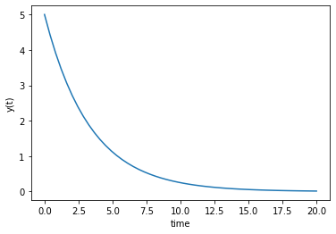

```python
import numpy as np
from scipy.integrate import odeint
import matplotlib.pyplot as plt

# function that returns dy/dt
def model(y,t):
    k = 0.3
    dydt = -k * y
    return dydt

# initial condition
ya = 5

# time points
a = 0
b = 20
N = 70
t = np.linspace(a,b,N)

# solve ODE
y = odeint(model,ya,t)

# plot results
plt.plot(t,y)
plt.xlabel('time')
plt.ylabel('y(t)')
plt.show()
```

# Solve the system of ODEs in python

Solve the simple differential systems, which consists of two variables and two differential equations and initial conditions x(t=0)=1, y(t=0)=2: \begin{equation} \begin{cases} \dfrac{d x}{d t}=5x-3y \\\\ \dfrac{d y}{d t}=-6x+2y \end{cases}, \text{ on } [0,1] \end{equation}

[figure not shown]

[figure not shown]

[figure not shown]

```python
import numpy as np
from scipy.integrate import odeint
import matplotlib.pyplot as plt

# function that returns dz/dt
def model(z,t):
    x,y = z
    dxdt = 5*x-3*y
    dydt = -6*x +2*y
    return dxdt,dydt

# initial condition
z0 = [1,2]

# time points
a = 0
b = 1
N = 100
t = np.linspace(a,b,N)

# solve ODE
z = odeint(model,z0,t)

x = z[:,0]
y = z[:,1]


# plot results
plt.subplot(3,1,1)
plt.plot(t,x)
plt.xlabel('time')
plt.ylabel('x(t)')
plt.show()
# plot results
plt.subplot(3,1,2)
plt.plot(t,y)
plt.xlabel('time')
plt.ylabel('y(t)')
plt.show()
# plot results
plt.subplot(3,1,3)
plt.plot(x,y)
plt.xlabel('x')
plt.ylabel('y')
plt.show()
```